# Gapminder Notebook

If needed, install the `kableExtra` package using:

```r
install.packages("kableExtra")
```

```r
library(tidyverse)
library(kableExtra)
library(rmarkdown)
```

Make sure you have a `data` folder in your working directory.

If required, download the data by running the following in the console:

```
download.file(url="https://raw.githubusercontent.com/mvanrongen/2020_Gates_Reproducibility/master/data/processed/gapminder_1950_2018.csv", destfile="data/gapminder_1950_2018.csv"
```

## Loading the data

Change the location depending on where your file is located. Here the `gapminder_notebook.Rmd` file is located within a `scripts` folder, so we have to navigate up one level `(../)` to be able to access the `data` folder.

```r
gapminder <- read_csv("../data/gapminder_1950_2018.csv")
```

### Dynamic tables using `rmarkdown`

```r
gapminder %>%
  paged_table()
```

| country_id | country | world_region | year | income_groups | income_per_person | life_expectancy |
| --- | --- | --- | --- | --- | --- | --- |
| afg | Afghanistan | south_asia | 1950 | low_income | 1040 | 32.0 |
| afg | Afghanistan | south_asia | 1951 | low_income | 1060 | 32.4 |
| afg | Afghanistan | south_asia | 1952 | low_income | 1070 | 33.0 |
| afg | Afghanistan | south_asia | 1953 | low_income | 1120 | 33.7 |
| afg | Afghanistan | south_asia | 1954 | low_income | 1130 | 34.4 |
| afg | Afghanistan | south_asia | 1955 | low_income | 1130 | 35.1 |
| afg | Afghanistan | south_asia | 1956 | low_income | 1160 | 35.8 |
| afg | Afghanistan | south_asia | 1957 | low_income | 1140 | 36.5 |
| afg | Afghanistan | south_asia | 1958 | low_income | 1180 | 37.2 |
| afg | Afghanistan | south_asia | 1959 | low_income | 1190 | 37.9 |

[output cut: 9990 more lines]

### Dynamic tables using `kableExtra`

```r
gapminder %>%
  filter(world_region == "america",
         year == 2018) %>%
  select(country, life_expectancy) %>%
  arrange(desc(life_expectancy)) %>%
  kable(caption = "Life expectancy in the Americas in 2018, descending") %>%
  kable_styling(bootstrap_options = c("striped", "hover"),
                full_width = FALSE) %>%
  scroll_box(width = "100%", height = "400px")
```

Life expectancy in the Americas in 2018, descending

| country | life_expectancy |
| --- | --- |
| Canada | 82.2 |
| Costa Rica | 81.4 |
| Chile | 80.7 |
| Peru | 80.2 |
| Panama | 79.4 |
| Cuba | 79.3 |
| United States | 79.1 |
| Nicaragua | 78.7 |
| Colombia | 78.6 |
| Ecuador | 78.3 |
| Antigua and Barbuda | 77.6 |
| Uruguay | 77.6 |
| Argentina | 77.0 |
| Barbados | 76.8 |
| Mexico | 76.8 |
| St. Lucia | 76.6 |
| Dominican Republic | 76.1 |
| Venezuela | 75.9 |
| El Salvador | 75.8 |
| Brazil | 75.7 |
| Jamaica | 75.2 |
| Paraguay | 74.8 |
| Bahamas | 74.1 |
| Bolivia | 74.0 |
| Trinidad and Tobago | 73.4 |
| Guatemala | 73.2 |
| Honduras | 73.1 |
| Belize | 72.5 |
| St. Vincent and the Grenadines | 72.0 |
| Grenada | 71.9 |
| Suriname | 71.6 |
| Guyana | 68.2 |
| Haiti | 64.5 |

### Challenge 1

We are interested in the possible relationship between income and longevity. To investigate this, we can use the `income_per_person` and `life_expectancy` variables.

Use your `gapminder_notebook.Rmd` R Notebook file to explore this further. First, we are going to do some plotting to get an idea of what the data look like. When doing this, remember to do the following:

- use clear headings (e.g. `# Exploratory analysis`, `## Investigating income vs life expectancy` etc. to break up your code/explanations).
- name your `` ``` {r} `` chunks to help you navigate through your code.

Try the following (preferably use pipes (`%>%` symbol) to get one data flow):

1. Filter the dataset for data from 2018 only (hint: use `filter`)
2. Plot using `ggplot()` a scatterplot of `income_per_person` vs `life_expectancy`
3. Colour the points by `income_group`
4. Facet the data by `world_region` (hint: use `facet_wrap`, see [documentation](https://ggplot2.tidyverse.org/reference/facet_wrap.html))
5. Look at the data and add some comments/observations.
6. Knit the document and see if the report looks like how you expected it to be.

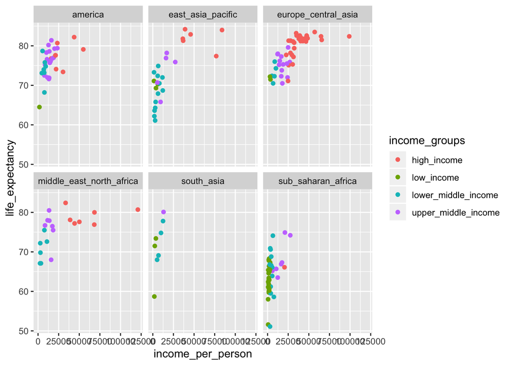

```r
gapminder %>%
  filter(year == 2018) %>%
  ggplot(aes(income_per_person, life_expectancy)) +
  geom_point(aes(colour = income_groups)) +
  facet_wrap(facets = vars(world_region))
```

Once you’ve managed to get this far, continue to Challenge 2.

### Challenge 2

From the 2018 data it is clear that there are some strong differences in income per country, even per world region.

It would be interesting to know which countries showed the highest income and in which year. Again, when doing this exercise, think about how you’re going to communicate to others what you are doing.

Try the following:

1. Find the highest income per `world_region` (hint: you’ll have to group and arrange the data).
2. Display only the highest income countr (hint: `slice()`)
3. Create a table using `kable()` in twitter-style with stripes and hover to display the data.

```r
gapminder %>%
  group_by(world_region) %>%
  arrange(desc(income_per_person)) %>%
  slice(1) %>%
  kable(caption = "Highest income per person, per world region") %>%
  kable_styling(bootstrap_options = c("striped", "hover"),
                full_width = TRUE)
```

Highest income per person, per world region

| country_id | country | world_region | year | income_groups | income_per_person | life_expectancy |
| --- | --- | --- | --- | --- | --- | --- |
| usa | United States | america | 2018 | high_income | 54900 | 79.1 |
| brn | Brunei | east_asia_pacific | 1979 | high_income | 146000 | 69.5 |
| lux | Luxembourg | europe_central_asia | 2018 | high_income | 99000 | 82.4 |
| are | United Arab Emirates | middle_east_north_africa | 1980 | high_income | 178000 | 70.8 |
| mdv | Maldives | south_asia | 2018 | upper_middle_income | 13000 | 80.1 |
| gnq | Equatorial Guinea | sub_saharan_africa | 2008 | high_income | 40000 | 59.8 |

```r
gapminder %>%
  filter(year == 2018,
         world_region == "america",
         income_groups == "low_income")
```

| country_id | country | world_region | year | income_groups | income_per_person | life_expectancy |
| --- | --- | --- | --- | --- | --- | --- |
| hti | Haiti | america | 2018 | low_income | 1710 | 64.5 |

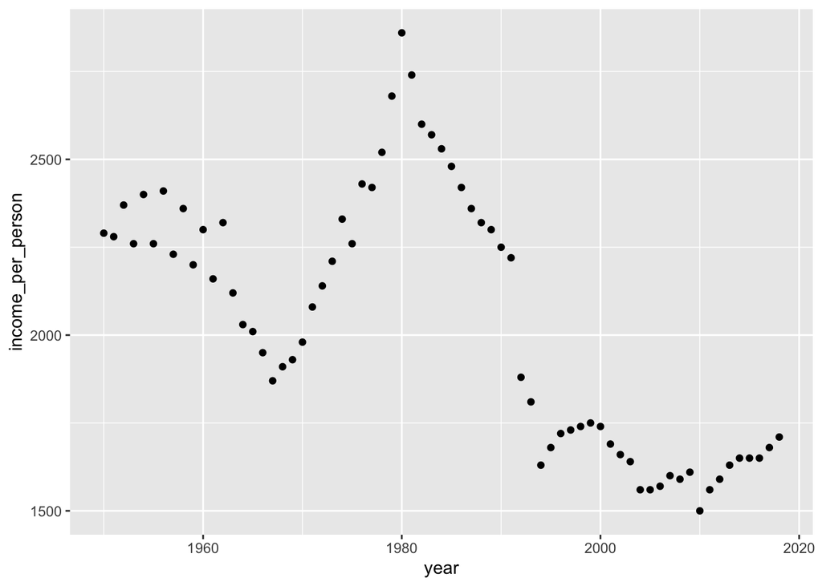

```r
gapminder %>%
  filter(country_id == "hti") %>%
  ggplot(aes(year, income_per_person)) +
  geom_point()
```